# Data_Analyst_ND_Project1

## P1: Stroop Effect

Tom Hrabchak  
November 2015

### Introduction

In a Stroop task, participants are presented with a list of words, with each word displayed in a color of ink. The participant’s task is to say out loud the color of the ink in which the word is printed. The task has two conditions: a congruent words condition, and an incongruent words condition. In the congruent words condition, the words being displayed are color words whose names match the colors in which they are printed. In the incongruent words condition, the words displayed are color words whose names do not match the colors in which they are printed. In each case, we measure the time it takes to name the ink colors in equally-sized lists. Each participant will go through and record a time from each condition.

The following image demonstrates both conditions. ("Stroop effect memory test") The first line shows the congruent words condition. The second line shows the incongruent words condition.

[figure not shown]

### Method

#### Design

In this study, we will be measuring the time in seconds it takes to name ink colors in equally sized lists for each participant in the two conditions. Our independent variable is the type of condition applied to the student, either the congruent condition or the incongruent condition. Our dependent variable is the time in seconds that it takes for the participant to name the ink colors in the list.

To analyze our hypothesis we will use a dependent samples t-test, also known as a paired t-test. Each participant will perform under two conditions, the congruent condition and incongruent condition. Our goal is to determine if the mean difference between the two conditions is significantly different from 0.

Although we have an intuitive sense that the effect will cause increased times for the incongruent condition group, we will use a two tailed test in case our intuition is incorrect.

We will use $\alpha = .05 $ to determine statistical significance.

#### Hypothesis

We want to determine if the mean difference between the two conditions is statistically significant. Therefore we will take the following as our hypothesis:

\begin{equation} H_0:\mu_D = \mu_2 - \mu_1 = 0 \end{equation}\begin{equation} H_a:\mu_D = \mu_2 - \mu_1 \neq 0 \end{equation}

where $\mu_1$ is the mean of the congruent condition, $\mu_2$ is the mean of the incongruent condition, and $\mu_D$ is the mean difference between the two conditions. If $\mu_D$ is significantly greater than 0, we can say that the incongruent condition resulted in longer times than the congruent condition. Likewise, if $\mu_D$ is significantly less than 0, we can say that the incongruent condition resulted in shorter times than the congruent condition.

### Analysis

In the first table (*Descriptive statistics of the two conditions*) we compare descriptive statistics of both conditions directly. We can see that the mean of the incongruent condition and the median of the incongruent condition are both greater than the mean of the congruent condition and the median of the congruent condition. Additionally we can see that the standard deviation of the incongruent condition is greater than the standard deviation of the congruent condition. This can also be viewed as a box plot (*Box Plot of Both Conditions*). The box plot shows that the incongruent condition has two outliers, in which the two outlier participants took unusually longer than other participants in the incongruent condition. The result of both conditions is shown as a histogram in *Histogram of Both Conditions*, which displays a uniform right shift from the congruent condition to the incongruent condtion.

The second table (*Descriptive statistics of the difference*) shows information on the paired difference of the two conditions. We can see that the mean difference between the incongruent condition and congruent condition was 7.96, meaning that on average the incongruent condition resulted in longer times than the congruent condition. The box plot of this information is shown in *Box Plot of the Difference*. In the *Histogram of the Difference*, the shape of the mean difference distribution is unclear and could be made clearer with more samples.

By performing our dependent samples t test, we found that the difference between the congruent and incongruent conditions was statistically significant. The test produced a t-statistic of 8.02 and a p-value of less than .01. Because we took our alpha as .05, and our p-value is less than alpha, we reject the null hypothesis that there is no difference between the incongruent and congruent conditions. Instead we accept the alternative hypothesis as it has been shown with above 95% confidence that there is a significant statistical difference between the congruent and incongruent conditions. This result aligns with our intuition that the incongruent condition would result in longer times than the congruent condition.

A potential explanation for the Stroop Effect is that there is a perceptual association of the text based image with it's color, and that association causes a delayed reaction in the incongruent condition. To further explore this explanation, it would be interesting to find if this effect extended to images or drawings other than text based images. We could test if drawings of animals or drawings of scenes that we traditionally associate with color (like a fire or an ice cube), results in a similar outcome to that of text based images. By performing these tests, we could create an index of our perceptual association of types of images with their color.

### Conclusion

In conclusion, by performing a dependent samples t test, we found that there is a significant statistical difference in the time it takes participants to recite colors from a set sized list between the congruent and incongruent conditions. By performing this study on a more generalized range of images, we could potentially further enhance our understanding of the implications of the Stroop Effect.

### References

Stroop effect memory test. (2013, November 13). Retrieved November 6, 2015, from https://commons.wikimedia.org/wiki/File:Stroop_effect_memory_test.png

### Appendix

```python
# Import Libraries
from scipy import stats
import pandas as pd
import matplotlib.pyplot as plt
plt.style.use('ggplot')

# Enable inline viewing of graphs
%matplotlib inline

# Load data from csv file
path = 'https://raw.githubusercontent.com/thrabchak/Udacity-Data-Analysis/master/P1%20Stroop%20Effect/stroopdata.csv'

# Parse csv into pandas data structures
dataFrame = pd.read_csv(path)
congruentSeries = dataFrame['Congruent']
incongruentSeries = dataFrame['Incongruent']

# Create a Series and DataFrame for the difference between the two conditions
differenceSeries = incongruentSeries - congruentSeries
differenceDataFrame = pd.DataFrame({"Difference":differenceSeries})
```

```python
# Descriptive statistics of the two conditions
dataFrame.describe()
```

|  | Congruent | Incongruent |
| --- | --- | --- |
| count | 24.000000 | 24.000000 |
| mean | 14.051125 | 22.015917 |
| std | 3.559358 | 4.797057 |
| min | 8.630000 | 15.687000 |
| 25% | 11.895250 | 18.716750 |
| 50% | 14.356500 | 21.017500 |
| 75% | 16.200750 | 24.051500 |
| max | 22.328000 | 35.255000 |

```python
# Descriptive statistics of the difference
differenceDataFrame.describe()
```

|  | Difference |
| --- | --- |
| count | 24.000000 |
| mean | 7.964792 |
| std | 4.864827 |
| min | 1.950000 |
| 25% | 3.645500 |
| 50% | 7.666500 |
| 75% | 10.258500 |
| max | 21.919000 |

```python
# Perform calculations for a dependent samples t test
ttestResults = stats.ttest_rel(incongruentSeries, congruentSeries)
tstatistic = ttestResults[0]
pvalue = ttestResults[1]
print "t-statistic = " + '%.2f' % tstatistic
print "p-value = " + '%.8f' % pvalue
```

```
t-statistic = 8.02
p-value = 0.00000004
```

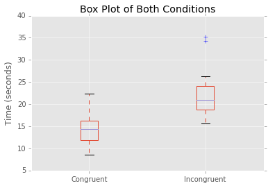

```python
# Box plots of the two conditions
title = 'Box Plot of Both Conditions'
kind = 'box'
dataFrame.plot(title=title, kind=kind)
ylabel = plt.ylabel('Time (seconds)')
```

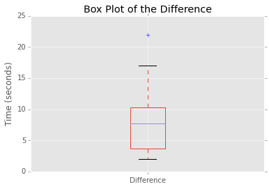

```python
# Box plots of the difference between the two conditions
title = 'Box Plot of the Difference'
kind = 'box'
differenceDataFrame.plot(title=title, kind=kind)
ylabel = plt.ylabel('Time (seconds)')
```

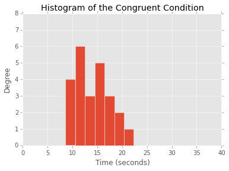

```python
# Histogram of the Congruent Condition
title = 'Histogram of the Congruent Condition'
kind = 'hist'
plot = congruentSeries.plot(title=title, kind=kind, bins=7)
xLabel = plt.xlabel('Time (seconds)')
window = plt.axis([0,40,0,8])
```

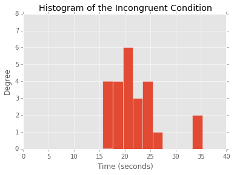

```python
# Histogram of the Incongruent Condition
title = 'Histogram of the Incongruent Condition'
kind = 'hist'
plot = incongruentSeries.plot(title=title, kind=kind)
xLabel = plt.xlabel('Time (seconds)')
window = plt.axis([0,40,0,8])
```

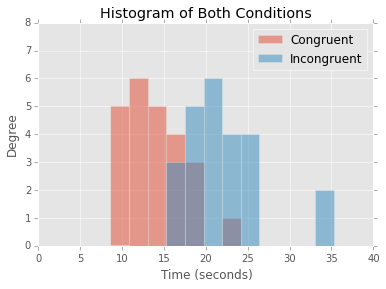

```python
# Histogram of Both Conditions
title = 'Histogram of Both Conditions'
kind = 'hist'
alpha = 0.5
plot = dataFrame.plot(title=title, kind=kind, alpha=alpha, bins=12)
xLabel = plt.xlabel('Time (seconds)')
window = plt.axis([0,40,0,8])
```

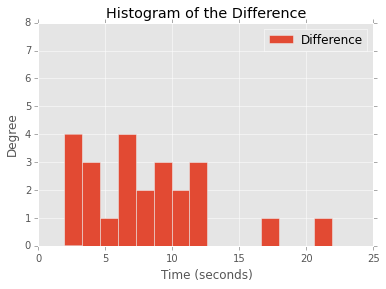

```python
# Histogram of the Difference between the Two Conditions
title = 'Histogram of the Difference'
kind = 'hist'
plot = differenceDataFrame.plot(title=title, kind=kind, bins=15)
xLabel = plt.xlabel('Time (seconds)')
window = plt.axis([0,25,0,8])
```

```python
# Display DataFrame generated from csv
dataFrame
```

|  | Congruent | Incongruent |
| --- | --- | --- |
| 0 | 12.079 | 19.278 |
| 1 | 16.791 | 18.741 |
| 2 | 9.564 | 21.214 |
| 3 | 8.630 | 15.687 |
| 4 | 14.669 | 22.803 |
| 5 | 12.238 | 20.878 |
| 6 | 14.692 | 24.572 |
| 7 | 8.987 | 17.394 |
| 8 | 9.401 | 20.762 |
| 9 | 14.480 | 26.282 |
| 10 | 22.328 | 24.524 |
| 11 | 15.298 | 18.644 |
| 12 | 15.073 | 17.510 |
| 13 | 16.929 | 20.330 |
| 14 | 18.200 | 35.255 |
| 15 | 12.130 | 22.158 |
| 16 | 18.495 | 25.139 |
| 17 | 10.639 | 20.429 |
| 18 | 11.344 | 17.425 |
| 19 | 12.369 | 34.288 |
| 20 | 12.944 | 23.894 |
| 21 | 14.233 | 17.960 |
| 22 | 19.710 | 22.058 |
| 23 | 16.004 | 21.157 |

```python
# Display DataFrame of the difference between the two conditions
differenceDataFrame
```

|  | Difference |
| --- | --- |
| 0 | 7.199 |
| 1 | 1.950 |
| 2 | 11.650 |
| 3 | 7.057 |
| 4 | 8.134 |
| 5 | 8.640 |
| 6 | 9.880 |
| 7 | 8.407 |
| 8 | 11.361 |
| 9 | 11.802 |
| 10 | 2.196 |
| 11 | 3.346 |
| 12 | 2.437 |
| 13 | 3.401 |
| 14 | 17.055 |
| 15 | 10.028 |
| 16 | 6.644 |
| 17 | 9.790 |
| 18 | 6.081 |
| 19 | 21.919 |
| 20 | 10.950 |
| 21 | 3.727 |
| 22 | 2.348 |
| 23 | 5.153 |

### Final Note

This report is a P1: Test a Perceptual Phenomenon submission for a Udacity Data Analysis Nanodegree. The introduction of this report is from the background section of the instructions for this report, which can be found [here](https://docs.google.com/document/d/1-OkpZLjG_kX9J6LIQ5IltsqMzVWjh36QpnP2RYpVdPU/pub?embedded=True). The dataset for this report was provided by udacity and can be found [here](https://www.google.com/url?q=https://drive.google.com/file/d/0B9Yf01UaIbUgQXpYb2NhZ29yX1U/view?usp%3Dsharing&sa=D&usg=AFQjCNGAjbK9VYD5GsQ8c_iRT9zH9QdOVg). To learn more about Udacity and their online classes go to http://www.udacity.com.